# Pitfall 3. Taking descriptive discrepancies for significant group differences

Bohan Zhang, Audran Feuvrier

27 November 2026

```r
suppressPackageStartupMessages({
  library(sechm)
  library(edgeR)
  library(dplyr)
  library(ComplexHeatmap)
  library(stageR)
  library(patchwork)
  library(ggplot2)
  library(ggpubr)
  library(ggrepel)
  library(rlang)
  library(cowplot)
  library(ggbeeswarm)
  library(RRHO2)
  library(magick)
  library(ggplotify)
})
wd <- "/mnt/gapp/work/bohan/transcriptional_sex_difference_analysis_pitfalls/bohan_ver"
setwd(wd)
knitr::opts_knit$set(root.dir = wd)
knitr::opts_chunk$set(warning = FALSE, class.message = "msg")
source("./code/function.R")
```

# 1 Function preparation

```r
#' Do differential expression analysis to test stress effect on a subset
#' @param se A SummarizedExperiment with a "counts" assay and colData column
#'   `Condition`, and optionally `SV1..SVn`.
#' @param effect What we are testing. (when doing stability test, choose "Condition"; when doing null comparison, choose "pseudoGroup" )
#' @param n.sv The number of surrogate variables that we use for latent variation correction. set to 0 if not using SVA
#' @return A data.frame from topTags() with every tested gene (logFC, logCPM,
#'   F, PValue, FDR), sorted by p-value; rownames are gene IDs.
stressDEA_for_subset <- function(se, effect, n.sv){
  dge <- DGEList(assay(se, "counts"))
  mm <- model.matrix(as.formula(paste("~ 0 + ", effect)), data=as.data.frame(colData(se)))
  dge <- calcNormFactors(dge)
  keep <- filterByExpr(dge, mm, min.count = 10)
  se <- se[keep, ]
  if(n.sv > 0){
    set.seed(1)
    suppressMessages(suppressWarnings(invisible(capture.output(
      se <- SEtools::svacor(se, as.formula(paste("~ 0 + ", effect)), n.sv = n.sv, method = "vst")))))
  }
  formula <- as.formula(paste(c(paste0(" ~ ", effect), grep("^SV[0-9]+$",colnames(colData(se)),value=TRUE)), collapse="+"))
  mm <- model.matrix(formula, data = as.data.frame(colData(se)))
  dge <- calcNormFactors(DGEList(assay(se)))
  dge <- estimateDisp(dge, mm)
  fit <- glmQLFit(dge, mm, pseudocount =0.5)
  if(effect == "Condition") {Results <- as.data.frame(topTags(glmQLFTest(fit, "ConditionStress"), Inf))} else {Results <- as.data.frame(topTags(glmQLFTest(fit, "pseudoGroupstress"), Inf))}
  return(Results)
}

#' Build a signed ranking metric from DE results (rank genes by sign(logFC) * -log10(p-value))
#' @param df A DE results table (e.g. from stressDEA_for_subset) with columns
#'   `logFC` and `PValue`; rownames are gene IDs.
#' @return The same table plus columns `gene` and `rank_metric`
rank_metrics <- function(df){
  df$gene <- rownames(df)
  df$rank_metric <- sign(df$logFC) * (-log10(df$PValue + 1e-300))
  df <- df[!is.na(df$rank_metric), ]
  df <- df[order(df$rank_metric, decreasing=TRUE), ]
  return(df)
}
```

# 2 Load data

We load the results generated in `02_baseline_bias.Rmd`.

```r
baseline_bias_se_obj <- readRDS("./objects/baseline_bias_se_obj.rds")
se_M <- baseline_bias_se_obj$male_baseline$SE
se_F <- baseline_bias_se_obj$female_baseline$SE
stress_degs_M <- baseline_bias_se_obj$male_baseline$DEGs$stress_DEGs  # stress DEGs from Male baseline analysis (Stress effect in Males)
stress_degs_F <- baseline_bias_se_obj$female_baseline$DEGs$stress_DEGs # stress DEGs from Female baseline analysis (Stress effect in Females)
df_M <- get_logFC_df(se_M, stress_degs_M, "Male baseline")
df_F <- get_logFC_df(se_F, stress_degs_F, "Female baseline")

# annotate the changing direction
d <- rbind(df_M, df_F)
d$set <- apply(as.matrix(d[,1:2]), 1, \(x){
  if(isNeg <- (sign(x)[which.max(abs(x))] < 0)) x <- -x
  paste0(ifelse(isNeg, "down ", "up "), ifelse(x[1]>x[2], "stronger\nin males", "stronger\nin females"))  # add sex difference annotation based on observed logFC magnitudes
  })
```

## 2.1 Visualize in reduced dataset

```r
# filter low counts and SVA correction for small (reduced) dataset, to be used for visualization
se <- readRDS("./datasets/small_vHC.rds")
dge <- DGEList(assay(se, "counts"))
mm <- model.matrix(~ 0 + group, data = as.data.frame(colData(se)))
dge <- calcNormFactors(dge)
# Filter lowly expressed genes
keep <- filterByExpr(dge, mm, min.count = 10)
# Subset SE to only filtered genes
se <- se[keep, ]
se <- SEtools::svacor(se, ~ 0 + group, n.sv = 2, method = "vst")
```

```
## Using variance-stabilizing transformation
```

```
## Number of significant surrogate variables is:  2
## Iteration (out of 5 ):1  2  3  4  5
```

```r
se <- log2FC(se, "corrected", controls = grep("Ctrl", se$group))
rownames(se) <- sub(".*\\.", "", rownames(se))
```

## 2.2 Fig 4A

Clusters are defined using observed logFC magnitudes. The conclusion of sex difference (i.e. stronger in one sex) emerged from descriptive summaries.

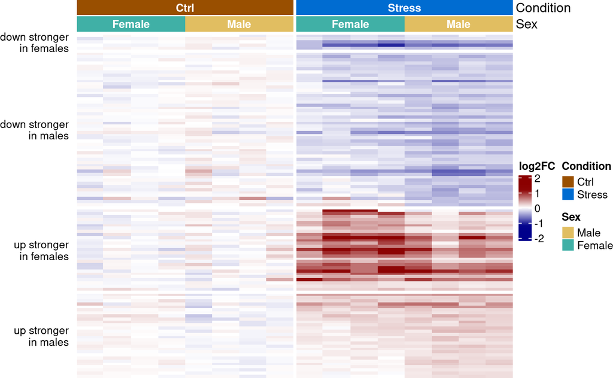

```r
fig4a <- sechm(
  se,
  split(d$gene, d$set),
  gaps_at = "Condition",
  top_annotation = c("Condition", "Sex"),
  anno_labels = TRUE,
  anno_label_gp = list(size = 10, col = "white"),
  column_title = NULL,
  row_title_rot = 0,
  row_title_gp = gpar(fontsize = 10),
  use_raster = "TRUE")
fig4a
```

## 2.3 Visualize in full dataset

The conclusion of sex difference based on descriptive statistics resulting from small (reduced) dataset is no longer exhibited in full dataset.

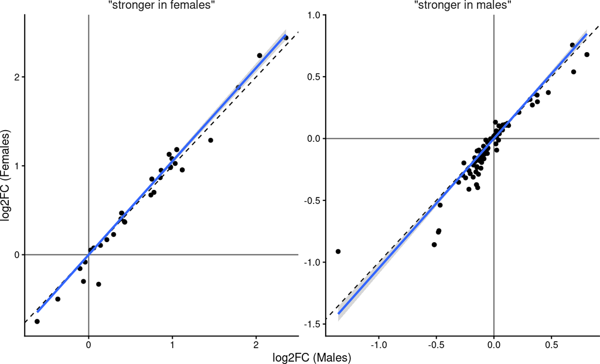

```r
full <- readRDS(file = "./objects/reference_analysis_obj.rds")
res <- full$edgeR
SE_full <- full$se
rownames(SE_full) = sub(".*\\.", "", rownames(SE_full))
SE_full$smallDataset <- colnames(SE_full) %in% colnames(se)
SE_full <- SE_full[,order(SE_full$Condition, SE_full$Sex, SE_full$smallDataset)]

res$gene <- sub(".*\\.", "", rownames(res))
m <- merge(res, d, by="gene")  # merge the DEG results from full dataset with the direction annotation from d
m$set2 <- paste0('"',gsub("\n", " ", gsub("up |down ", "", m$set)),'"')   # this is only for annotation. (removing "up"/"down", only keep "stronger in females/males")

fig4b <- ggplot(m, aes(logFC.M_Stress, logFC.F_Stress)) +
  geom_abline(slope = 1, intercept = 0, color = "black", linetype = "dashed") +
  geom_vline(xintercept = 0, color = "gray40") +
  geom_hline(yintercept = 0, color = "gray40") +
  geom_point() +
  geom_smooth(method = MASS::rlm, formula = y ~ 0 + x) +
  facet_wrap(~set2, scales = "free") +
  xlab("log2FC (Males)") + ylab("log2FC (Females)") +
  theme_classic() +
  theme(strip.background = element_blank(), strip.text = element_text(size=11))
fig4b
```

# 3 Rank-Rank Hypergeometric Overlap (RRHO)

RRHO is commonly used to compare genome-wide signatures. Ranking of genes based on DEA results is used to assess the similarity/difference of two subset in a descriptive manner (Plaisier et al. 2010; Cahill et al. 2018).

## 3.1 Ranking instability from small sample size

When the method compares logFCs coming from small samples, a single sample in one comparison can skew the entire ranking, giving the false impression of a very different response. Or a wrongly similar one for that matter.

We sample 4 Stress vs. 4 Ctrl of males, and another 4 Stress vs. 4 Ctrl of males, to show the instability

To demonstrate: The ranking of genes in response to stress is unstable — two draws from the same experiment give different, even opposite, stress signatures.

(see Section 5 for all permutations)

### 3.1.1 No SVA correction

```r
# sampling 4 Stress vs 4 ctrl twice from male

se <- readRDS("./datasets/whole_vHC_dataset.rds")
rrho_rank_instability_noSVA <- list()
for (seed in 111:120){
  set.seed(seed)

  eligible_exp <- unique(se$Experiment)
  eligible_exp <- eligible_exp[eligible_exp != "vonZiegler.E3"]  # There are only 3 male stress sample in this experiment. So we exclude it
  # Random sampling 1
  # first pick up an Exp
  exp1 <- sample(eligible_exp, 1)

  # get available male samples from exp1
  m_stress_exp1 <- colnames(se)[se$group == "Male_Stress" & se$Experiment == exp1]
  m_ctrl_exp1 <- colnames(se)[se$group == "Male_Ctrl" & se$Experiment == exp1]

  # Random sampling subset 1
  s1 <- sample(m_stress_exp1, 4)
  c1 <- sample(m_ctrl_exp1, 4)
  used <- c(s1, c1) # record it to ensure that later the second subset don't overlap with the first one

  # pick experiment for subset 2 (can be same or different)
  if(exp1 %in% c("vonZiegler.E2", "Floriou-servou.E2")){ # these two Exp don't have enough samples for two independent subsets. So if in sampling 1 we used them, we can't use them in sampling2
    exp2 <- sample(setdiff(eligible_exp, c("vonZiegler.E2", "Floriou-servou.E2")), 1)
  } else {
    exp2 <- sample(eligible_exp, 1)  # otherwise we can sample from the same Exp
  }

  # get available male samples from exp2, excluding already used samples (make sure they don't overlap with the first sampling)
  m_stress_exp2 <- setdiff(colnames(se)[se$group == "Male_Stress" & se$Experiment == exp2], used)
  m_ctrl_exp2 <- setdiff(colnames(se)[se$group == "Male_Ctrl" & se$Experiment == exp2], used)

  # Random sampling subset 2
  s2 <- sample(m_stress_exp2, 4)
  c2 <- sample(m_ctrl_exp2, 4)

  # Optional: report sampling details
  # cat("  Subset 1 | Experiment:", exp1, "\n")
  # cat("    Stress:", paste(s1, collapse=", "), "\n")
  # cat("    Ctrl:  ", paste(c1, collapse=", "), "\n")
  # cat("  Subset 2 | Experiment:", exp2, "\n")
  # cat("    Stress:", paste(s2, collapse=", "), "\n")
  # cat("    Ctrl:  ", paste(c2, collapse=", "), "\n")
  # cat("  Overlap check:", length(intersect(c(s1,c1), c(s2,c2))), "shared samples (should be 0)\n\n")

  se1 <- se[, c(s1, c1)]
  se2 <- se[, c(s2, c2)]

  # differential analysis
  # first random sampling
  Results_Condition_se1 <- stressDEA_for_subset(se1, effect = "Condition", n.sv = 0)

  # differential analysis
  # Second random sampling
  Results_Condition_se2 <- stressDEA_for_subset(se2, effect = "Condition", n.sv = 0)

  # ranking metrics
  Results_Condition_se1 <- rank_metrics(Results_Condition_se1)
  Results_Condition_se2 <- rank_metrics(Results_Condition_se2)

  # ---- RRHO2 ----
  list1 <- Results_Condition_se1[, c("gene", "rank_metric")]
  list2 <- Results_Condition_se2[, c("gene", "rank_metric")]

  common_genes <- intersect(list1$gene, list2$gene)
  list1 <- list1[list1$gene %in% common_genes,]
  list2 <- list2[list2$gene %in% common_genes,]

  rrho_out <- RRHO2_initialize(list1, list2,
                                labels = c("subset 1 (4 Stress vs. 4 Ctrl)", "subset 2 (4 Stress vs. 4 Ctrl)"),
                                log10.ind = TRUE)
    rrho_out$sampleInfo <- list(
    expA = exp1,
    expB = exp1,
    se1_ctrl   = s1,
    se1_stress = c1,
    se2_ctrl   = s2,
    se2_stress = c2
  )
  rrho_rank_instability_noSVA[[paste0("seed_", seed)]] <- rrho_out  # save all the results
}

saveRDS(rrho_rank_instability_noSVA, "./supplements/RRHO_attempts/rrho_rank_instability_noSVA.rds", compress="xz")
```

### 3.1.2 Using SVA correction

Applying correction for latent variations (Leek and Storey 2007; Leek et al. 2012) mitigated part of the sample variability, and in turn improved the stability of RRHO results

```r
# sampling 4 Stress vs 4 ctrl twice from male

se <- readRDS("./datasets/whole_vHC_dataset.rds")
rrho_rank_instability_SVA <- list()
for (seed in 111:120){
  set.seed(seed)

  eligible_exp <- unique(se$Experiment)
  eligible_exp <- eligible_exp[eligible_exp != "vonZiegler.E3"]  # There are only 3 male stress sample in this experiment. So we exclude it
  # Random sampling 1
  # first pick up an Exp
  exp1 <- sample(eligible_exp, 1)

  # get available male samples from exp1
  m_stress_exp1 <- colnames(se)[se$group == "Male_Stress" & se$Experiment == exp1]
  m_ctrl_exp1 <- colnames(se)[se$group == "Male_Ctrl" & se$Experiment == exp1]

  # Random sampling subset 1
  s1 <- sample(m_stress_exp1, 4)
  c1 <- sample(m_ctrl_exp1, 4)
  used <- c(s1, c1) # record it to ensure that later the second subset don't overlap with the first one

  # pick experiment for subset 2 (can be same or different)
  if(exp1 %in% c("vonZiegler.E2", "Floriou-servou.E2")){ # these two Exp don't have enough samples for two independent subsets. So if in sampling 1 we used them, we can't use them in sampling2
    exp2 <- sample(setdiff(eligible_exp, c("vonZiegler.E2", "Floriou-servou.E2")), 1)
  } else {
    exp2 <- sample(eligible_exp, 1)  # otherwise we can sample from the same Exp
  }

  # get available male samples from exp2, excluding already used samples (make sure they don't overlap with the first sampling)
  m_stress_exp2 <- setdiff(colnames(se)[se$group == "Male_Stress" & se$Experiment == exp2], used)
  m_ctrl_exp2 <- setdiff(colnames(se)[se$group == "Male_Ctrl" & se$Experiment == exp2], used)

  # Random sampling subset 2
  s2 <- sample(m_stress_exp2, 4)
  c2 <- sample(m_ctrl_exp2, 4)

  # Optional: report sampling details
  # cat("  Subset 1 | Experiment:", exp1, "\n")
  # cat("    Stress:", paste(s1, collapse=", "), "\n")
  # cat("    Ctrl:  ", paste(c1, collapse=", "), "\n")
  # cat("  Subset 2 | Experiment:", exp2, "\n")
  # cat("    Stress:", paste(s2, collapse=", "), "\n")
  # cat("    Ctrl:  ", paste(c2, collapse=", "), "\n")
  # cat("  Overlap check:", length(intersect(c(s1,c1), c(s2,c2))), "shared samples (should be 0)\n\n")

  se1 <- se[, c(s1, c1)]
  se2 <- se[, c(s2, c2)]

  # differential analysis
  # first random sampling
  Results_Condition_se1 <- stressDEA_for_subset(se1, effect = "Condition", n.sv = 1)    # we use 1 SVs for this analysis since the sample size is small

  # differential analysis
  # Second random sampling
  Results_Condition_se2 <- stressDEA_for_subset(se2, effect = "Condition", n.sv = 1)

  # ranking metrics
  Results_Condition_se1 <- rank_metrics(Results_Condition_se1)
  Results_Condition_se2 <- rank_metrics(Results_Condition_se2)

  # ---- RRHO2 ----
  list1 <- Results_Condition_se1[, c("gene", "rank_metric")]
  list2 <- Results_Condition_se2[, c("gene", "rank_metric")]

  common_genes <- intersect(list1$gene, list2$gene)
  list1 <- list1[list1$gene %in% common_genes,]
  list2 <- list2[list2$gene %in% common_genes,]

  rrho_out <- RRHO2_initialize(list1, list2,
                                labels = c("subset 1 (4 Stress vs. 4 Ctrl)", "subset 2 (4 Stress vs. 4 Ctrl)"),
                                log10.ind = TRUE)
  rrho_out$sampleInfo <- list(
    expA = exp1,
    expB = exp1,
    se1_ctrl   = s1,
    se1_stress = c1,
    se2_ctrl   = s2,
    se2_stress = c2
  )
  rrho_rank_instability_SVA[[paste0("seed_", seed)]] <- rrho_out  # save all the results
}

saveRDS(rrho_rank_instability_SVA, "./supplements/RRHO_attempts/rrho_rank_instability_SVA.rds", compress="xz")
```

## 3.2 Null experiment (taking 4vs4 ctrl males randomly)

To demonstrate: when used on (signed) p-values, other factors influencing the p-values (like mean expression level) create a misleading sense of similarity.

```r
se <- readRDS("./datasets/whole_vHC_dataset.rds")
rrho_null_exp <- list()
eligible_exp <- names(which(  # we choose the Exp that have enough samples
  table(se$Experiment[se$group == "Male_Ctrl"]) >= 8
))
eligible_exp
```

```
## [1] "Floriou-servou.E1" "Privitera.E1"      "Privitera.E2"
## [4] "vonZiegler.E1"
```

```r
for (seed in 221:230){
  set.seed(seed)

  # pick 2 experiments
  exp_pair <- sample(eligible_exp, 2, replace = FALSE)
  expA <- exp_pair[1]
  expB <- exp_pair[2]

  # decide how many to take from each exp. Here we keep the number even, since we also want to balance the composition of our pseudo group later)
  # n_A + n_B = 16 total (8 per subset x 2)
  # Actually the only possible draw is 8 from ExpA and 8 from ExpB. Subset1 = 4A + 4B, Subset2 = 4A + 4B
  pool_A <- colnames(se)[se$group == "Male_Ctrl" & se$Experiment == expA]
  pool_B <- colnames(se)[se$group == "Male_Ctrl" & se$Experiment == expB]

  # draw 8 from each exp, 4 for se1, 4 for se2
  drawn_A <- sample(pool_A, 8, replace = FALSE)
  drawn_B <- sample(pool_B, 8, replace = FALSE)

  # se1: 4 from expA + 4 from expB, split 2+2 into pseudo_ctrl and pseudo_stress
  se1_ctrl   <- c(drawn_A[1:2], drawn_B[1:2])
  se1_stress <- c(drawn_A[3:4], drawn_B[3:4])

  # se2: remaining 4 from expA + 4 from expB, same split
  se2_ctrl   <- c(drawn_A[5:6], drawn_B[5:6])
  se2_stress <- c(drawn_A[7:8], drawn_B[7:8])

  # generate two subsets
  se1 <- se[, c(se1_ctrl, se1_stress)]
  se1$pseudoGroup <- factor(c(rep("ctrl", 4), rep("stress", 4)), levels = c("ctrl", "stress"))

  se2 <- se[, c(se2_ctrl, se2_stress)]
  se2$pseudoGroup <- factor(c(rep("ctrl", 4), rep("stress", 4)), levels = c("ctrl", "stress"))

  # Optional: report sampling details
  # cat("Permutation", seed, ":\n")
  # cat("  Exp A:", expA, "| Exp B:", expB, "\n")
  # cat("  se1 ctrl (n=4):  ", paste(se1_ctrl, collapse=", "), "\n")
  # cat("  se1 stress (n=4):", paste(se1_stress, collapse=", "), "\n")
  # cat("  se2 ctrl (n=4):  ", paste(se2_ctrl, collapse=", "), "\n")
  # cat("  se2 stress (n=4):", paste(se2_stress, collapse=", "), "\n")
  # cat("  Overlap se1/se2:", length(intersect(colnames(se1), colnames(se2))), "(should be 0)\n\n")

  # differential analysis
  # first random sampling
  Results_Condition_se1 <- stressDEA_for_subset(se1, effect  = "pseudoGroup", n.sv = 1)

  # Second random sampling
  Results_Condition_se2 <- stressDEA_for_subset(se2, effect  = "pseudoGroup", n.sv = 1)

  # ranking metrics
  Results_Condition_se1 <- rank_metrics(Results_Condition_se1)
  Results_Condition_se2 <- rank_metrics(Results_Condition_se2)

  # ---- RRHO2 ----
  list1 <- Results_Condition_se1[, c("gene", "rank_metric")]
  list2 <- Results_Condition_se2[, c("gene", "rank_metric")]

  common_genes <- intersect(list1$gene, list2$gene)
  list1 <- list1[list1$gene %in% common_genes,]
  list2 <- list2[list2$gene %in% common_genes,]

  rrho_out <- RRHO2_initialize(list1, list2,
                                labels = c("subset 1 (n=8 from male Ctrl)", "subset 2 (n=8 from male Ctrl)"),
                                log10.ind = TRUE)
  rrho_out$sampleInfo <- list(
    expA = expA,
    expB = expB,
    se1_ctrl   = se1_ctrl,
    se1_stress = se1_stress,
    se2_ctrl   = se2_ctrl,
    se2_stress = se2_stress
  )
  rrho_null_exp[[paste0("seed_", seed)]] <- rrho_out  # save all the results
}
saveRDS(rrho_null_exp, "./supplements/RRHO_attempts/rrho_null_exp.rds", compress="xz")
```

In this case, we expect no signal (a completely blue map), since all the pvalue from this random dataset should be random. (see Section 5 for all permutations)

# 4 Fig 4 summary

[figure not shown]

```r
# first we plot the RRHO heatmap manually, to make it easier to adjust to the figure.
# to simply check the plot, you can use the function RRHO2_heatmap() from the package
# here we set the color gradients same as in the package
jet.colors <- colorRampPalette(c("#00007F", "blue", "#007FFF", "cyan", "#7FFF7F", "yellow", "#FF7F00", "red", "#7F0000"))

# set the range the same for the first two heatmaps
colorGradient <- jet.colors(101)
global_max1 <- 170
col_fun_rank_instability <- circlize::colorRamp2(seq(0, global_max1, length.out = 101), colorGradient)
# set another range for the third heatmap
col_fun_null <- circlize::colorRamp2(seq(0, 60, length.out = 101), colorGradient)

# three examples in Fig 4
list4c1 <- rrho_rank_instability_noSVA[["seed_114"]]
list4c2 <- rrho_rank_instability_noSVA[["seed_115"]]
list4d <- rrho_null_exp[["seed_226"]]

mat4c1 <- make_better_RRHO_matrix(list4c1$hypermat)
fig4c1 <- RRHO_plot(mat4c1, colorFun = col_fun_rank_instability, col_title = "subset 1 (4 Stress vs. 4 Ctrl)", row_title = "subset 2 (4 Stress vs. 4 Ctrl)", show_legend = FALSE)

mat4c2 <- make_better_RRHO_matrix(list4c2$hypermat)
fig4c2 <- RRHO_plot(mat4c2, colorFun = col_fun_rank_instability, col_title = "subset 3 (4 Stress vs. 4 Ctrl)", row_title = "subset 4 (4 Stress vs. 4 Ctrl)",
            heatmap_legend_param = list(direction = "vertical", title_position = "leftcenter-rot",  # rotates title 90 degrees
            legend_height = unit(6, "cm")))

mat4d <- make_better_RRHO_matrix(list4d$hypermat)
fig4d <- RRHO_plot(mat4d, colorFun = col_fun_null, col_title = "subset 1 (4 Ctrl vs. 4 Ctrl)", row_title = "subset 2 (4 Ctrl vs. 4 Ctrl)",
            heatmap_legend_param = list(direction = "vertical", title_position = "leftcenter-rot",  # rotates title 90 degrees
            legend_height = unit(6, "cm")))

title_rank_instability <- ggplot() + annotate("text", x = 0.5, y = 0.5, label = "Independent Subsamples From The Same Comparison\nShow Inconsistent RRHO Patterns", fontface = "bold", size = 4) + theme_void()
title_null_exp <- ggplot() + annotate("text", x = 0.5, y = 0.5, label = "Null Comparison Shows\nStructured RRHO Pattern", fontface = "bold", size = 4) + theme_void()

fig4 <- plot_grid(
          plot_grid(
            as.ggplot(function() draw(fig4a, merge_legends = TRUE)),
            fig4b,
            nrow = 1, labels = c("A", "B"), scale = c(0.9, 0.95)),
          plot_grid(title_rank_instability, title_null_exp, nrow = 1, rel_widths = c(1.8, 1), labels = c("C", "D")),
          plot_grid(
            plotlist = lapply(list(fig4c1, fig4c2, fig4d), \(x) grid.grabExpr(draw(x), wrap = TRUE, wrap.grobs = TRUE)),
            nrow = 1, rel_widths = c(0.85, 1, 1)),
          nrow = 3, rel_heights = c(1, 0.15, 1))
fig4
```

```r
pdf("./figures/fig4_descriptive_pitfall.pdf", width = 10, height = 8)
fig4
dev.off()
```

# 5 Supplement - RRHO permutations summary

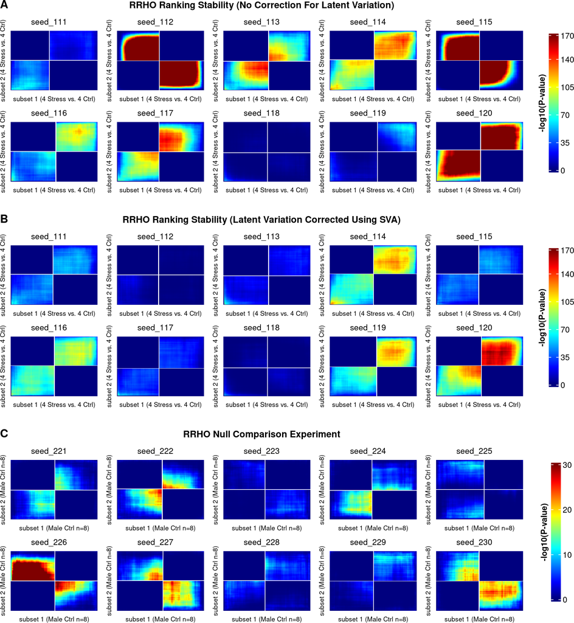

```r
jet.colors <- colorRampPalette(c("#00007F", "blue", "#007FFF", "cyan", "#7FFF7F", "yellow", "#FF7F00", "red", "#7F0000"))

# set the range
colorGradient <- jet.colors(101)
global_max1 <- 170   # for instability panels
col_fun_rank_instability <- circlize::colorRamp2(seq(0, global_max1, length.out = 101), colorGradient)
global_max2 <- 30  # for null comparison panels
col_fun_null <- circlize::colorRamp2(seq(0, global_max2, length.out = 101), colorGradient)

rrho_rank_instability_noSVA <- readRDS("./supplements/RRHO_attempts/rrho_rank_instability_noSVA.rds")
rrho_rank_instability_SVA <- readRDS("./supplements/RRHO_attempts/rrho_rank_instability_SVA.rds")
rrho_null_exp <- readRDS("./supplements/RRHO_attempts/rrho_null_exp.rds")


ht_list_rank_instability_noSVA <- lapply(names(rrho_rank_instability_noSVA), function(seed_name) {
  mat <- make_better_RRHO_matrix(rrho_rank_instability_noSVA[[seed_name]]$hypermat)
  ht  <- RRHO_plot(mat, colorFun = col_fun_rank_instability,
                   col_title = "subset 1 (4 Stress vs. 4 Ctrl)",
                   row_title = "subset 2 (4 Stress vs. 4 Ctrl)",
                   fontsize = 8, show_legend = FALSE)
  grid.grabExpr(draw(ht, column_title = seed_name, column_title_gp = gpar(fontsize = 10)),
                wrap = TRUE, wrap.grobs = TRUE)
})

title_rank_stability_noSVA <- ggplot() + annotate("text", x = 0.5, y = 0.5, label = "RRHO Ranking Stability (No Correction For Latent Variation)", fontface = "bold", size = 4) + theme_void()

ht_list_rank_instability_SVA <- lapply(names(rrho_rank_instability_SVA), function(seed_name) {
  mat <- make_better_RRHO_matrix(rrho_rank_instability_SVA[[seed_name]]$hypermat)
  ht  <- RRHO_plot(mat, colorFun = col_fun_rank_instability,
                   col_title = "subset 1 (4 Stress vs. 4 Ctrl)", row_title = "subset 2 (4 Stress vs. 4 Ctrl)",
                   fontsize = 8, show_legend = FALSE)
  grid.grabExpr(draw(ht, column_title = seed_name, column_title_gp = gpar(fontsize = 10)),
                wrap = TRUE, wrap.grobs = TRUE)
})

title_rank_stability_SVA <- ggplot() + annotate("text", x = 0.5, y = 0.5, label = "RRHO Ranking Stability (Latent Variation Corrected Using SVA)", fontface = "bold", size = 4) + theme_void()


ht_list_null_exp <- lapply(names(rrho_null_exp), function(seed_name) {
  mat <- make_better_RRHO_matrix(rrho_null_exp[[seed_name]]$hypermat)
  ht  <- RRHO_plot(mat, colorFun = col_fun_null,
                   col_title = "subset 1 (Male Ctrl n=8)", row_title = "subset 2 (Male Ctrl n=8)",
                   fontsize = 8, show_legend = FALSE)
  grid.grabExpr(draw(ht, column_title = seed_name, column_title_gp = gpar(fontsize = 10)),
                wrap = TRUE, wrap.grobs = TRUE)
})

title_null_exp <- ggplot() + annotate("text", x = 0.5, y = 0.5, label = "RRHO Null Comparison Experiment", fontface = "bold", size = 4) + theme_void()

legend_rank_instabitliy <- grid.grabExpr(
  draw(
    Heatmap(matrix(seq(0, global_max1, length.out = 10)),
            col = col_fun_rank_instability,
            name = "-log10(P-value)",
            heatmap_legend_param = list(
              direction = "vertical",
              title_position = "leftcenter-rot",
              legend_height = unit(6, "cm"),
              at = c(0, 35, 70, 105, 140, 170),
              labels = c("0", "35", "70", "105", "140", "170")),
            show_heatmap_legend = TRUE,
            show_row_dend = FALSE,
            show_column_dend = FALSE,
            show_row_names = FALSE,
            show_column_names = FALSE,
            width = unit(0, "cm"),
            height = unit(0, "cm")),
    heatmap_legend_side = "right"
  ), wrap = TRUE, wrap.grobs = TRUE)

legend_null <- grid.grabExpr(
  draw(
    Heatmap(matrix(seq(0, global_max2, length.out = 10)),
            col = col_fun_null,
            name = "-log10(P-value)",
            heatmap_legend_param = list(
              direction = "vertical",
              title_position = "leftcenter-rot",
              legend_height = unit(6, "cm")),
            show_heatmap_legend = TRUE,
            show_row_dend = FALSE,
            show_column_dend = FALSE,
            show_row_names = FALSE,
            show_column_names = FALSE,
            width = unit(0, "cm"),
            height = unit(0, "cm")),
    heatmap_legend_side = "right"
  ), wrap = TRUE, wrap.grobs = TRUE)

spacer <- ggplot() + theme_void()

supp_fig1_RRHO <- plot_grid(
      plot_grid(
        plot_grid(
          title_rank_stability_noSVA,
          plot_grid(plotlist = ht_list_rank_instability_noSVA[1:5], nrow = 1),
          plot_grid(plotlist = ht_list_rank_instability_noSVA[6:10], nrow = 1),
          spacer,
          nrow = 4, rel_heights = c(0.2, 1, 1, 0.15)),
        plot_grid(
          title_rank_stability_SVA,
          plot_grid(plotlist = ht_list_rank_instability_SVA[1:5], nrow = 1),
          plot_grid(plotlist = ht_list_rank_instability_SVA[6:10], nrow = 1),
          spacer,
          nrow = 4, rel_heights = c(0.2, 1, 1, 0.15)),
        plot_grid(
          title_null_exp,
          plot_grid(plotlist = ht_list_null_exp[1:5], nrow = 1),
          plot_grid(plotlist = ht_list_null_exp[6:10], nrow = 1),
          spacer,
          nrow = 4, rel_heights = c(0.2, 1, 1, 0.15)),
        nrow = 3,
        ncol = 1,
        labels = c("A", "B", "C")
      ),
      plot_grid(legend_rank_instabitliy, legend_rank_instabitliy, legend_null, ncol = 1),
      nrow = 1,
      rel_widths = c(1, 0.1)
    )
supp_fig1_RRHO
```

```r
pdf("./supplements/supp_fig1_RRHO.pdf", width = 10, height = 11)
supp_fig1_RRHO
dev.off()
```

# Reference

Cahill, Kelly M., Zhiguang Huo, George C. Tseng, Ryan W. Logan, and Marianne L. Seney. 2018. “Improved Identification of Concordant and Discordant Gene Expression Signatures Using an Updated Rank-Rank Hypergeometric Overlap Approach.” *Scientific Reports* 8 (1): 9588. https://doi.org/10.1038/s41598-018-27903-2.

Leek, Jeffrey T., W. Evan Johnson, Hilary S. Parker, Andrew E. Jaffe, and John D. Storey. 2012. “The Sva Package for Removing Batch Effects and Other Unwanted Variation in High-Throughput Experiments.” *Bioinformatics* 28 (6): 882–83. https://doi.org/10.1093/bioinformatics/bts034.

Leek, Jeffrey T., and John D. Storey. 2007. “Capturing Heterogeneity in Gene Expression Studies by Surrogate Variable Analysis.” *PLoS Genetics* 3 (9): 1724–35. https://doi.org/10.1371/journal.pgen.0030161.

Plaisier, Seema B., Richard Taschereau, Justin A. Wong, and Thomas G. Graeber. 2010. “Rank–Rank Hypergeometric Overlap: Identification of Statistically Significant Overlap Between Gene-Expression Signatures.” *Nucleic Acids Research* 38 (17): e169. https://doi.org/10.1093/nar/gkq636.